# Activity - Interpolation

Solutions

```r
library(pracma)
```

### Objectives

- Implement methods of polynomial interpolation
- Explore their error

### Procedure

- Please collaborate on this activity with one person as scribe (typist). There should only be one laptop open. We’re aiming for actual collaboration here, not two or three people working in parallel.
- It doesn’t matter if you finish the whole activity during class.
- It **does** mater if you focus on helping each other learn. Helping each other learn is the point of this activity. Completing the problems is merely a mechanism to guide you towards learning.
- It **does** mater if everyone participates. The expectation is that every group member participates, where the definition of “participation” can include asking questions, answering questions, brainstorming, or any other form of meaningful engagement.
- In the last three minutes of class, before you leave, please knit your .Rmd file to html, print the html to .pdf, and have the scribe submit it as a group assignment through GLOW.
- Don’t forget that the solutions are available on GLOW.

### Problem 0

Recalling that academic integrity policies apply even in an ungraded course, please disclose any irregular circumstances related to participation in your group (for instance, a group member was missing and did not contribute to this document).

### Problem 0 Solution

Your solution goes here.

### Problem 1

Consider the points (-2,0), (-1,14), (2,-4), (3,10).

1. Find the interpolating polynomial in R, using the Vandermonde method. Also, evaluate your polynomial at the point x = 1.5 by using the build-in `horner` command. Make sure you pay attention to what order your coefficients are in after solving the Vandermonde problem, and what order the `horner` function expects them it.
2. Find the interpolating polynomial by hand, using the Lagrange method. Simplify your answer to show that it is the same polynomial you obtained in part a. You can use WolframAlpha or a similar tool to help you simplify it.
3. Write code to perform interpolation using the Lagrange method. Your code should take the following as inputs:
- a vector `xsample` containing coordinates of the interpolation points
- a vector `ysample` containing the y coordinates of the interpolation points
- a vector `xgrid` containing the x coordinates of the points at which you want to evaluate the interpolating polynomial

The code should output a vector the values of the Lagrange interpolating polynomial at the points in `xgrid`.

Plot the interpolating polynomial using 30 equally spaced points from x = -2 to x = 3. Make the polynomial appear as a curve and add the original four sampled values as points.

### Problem 1 solution

```r
vandermonde <- function(x) {
  A <- outer(x, (length(x)):1 - 1, "^")
  return(A)
}
x <- c(-2,-1,2,3)
y <- c(0,14,-4,10)
A <- vandermonde(x)
coeffs <- solve(A,y)
paste(paste0(coeffs,paste0("x^",length(x):1 - 1)), collapse = " + ")
```

```
## [1] "2x^3 + -3x^2 + -9x^1 + 10x^0"
```

```r
horner(coeffs,1.5)$y
```

```
## [1] -3.5
```

$$\begin{eqnarray}
P(x) & = & 0 \cdot \frac{(x+1)(x-2)(x-3)}{(-2+1)(-2-2)(-2-3)} +
14 \cdot \frac{(x+2)(x-2)(x-3)}{(-1+2)(-1-2)(-1-3)} -4 \cdot
\frac{(x+2)(x+1)(x-3)}{(2+2)(2+1)(2-3)} + 10 \cdot
\frac{(x+2)(x+1)(x-2)}{(3+2)(3+1)(3-2)} \\
& = & 0 + \frac{7}{6}\left(x^3-3x^2-4x+12\right) + \frac{1}{3}
\left(x^3 - 7x - 6\right) +\frac{1}{2}\left(x^3+x^2-4x-4\right) \\
& = & 2x^3 - 3x^2 -9x + 10
\end{eqnarray}$$

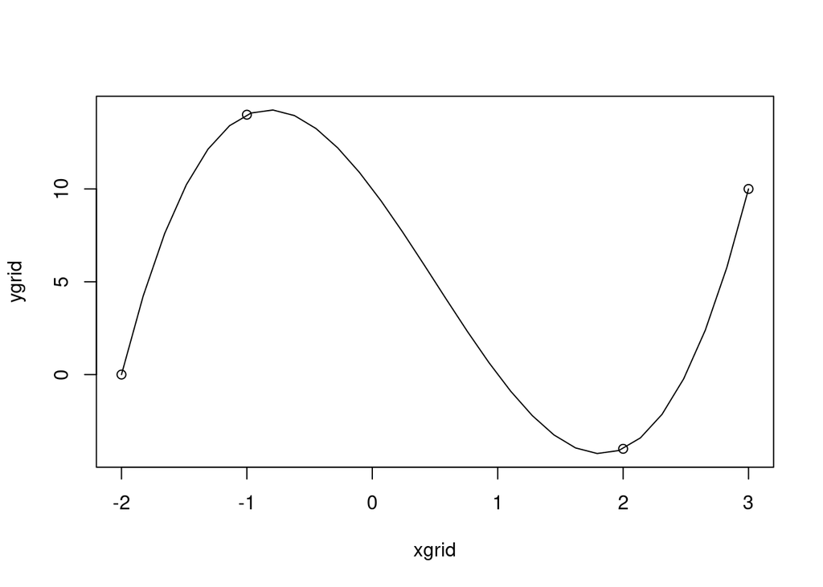

```r
lagrange <- function(xsample, ysample, xgrid){
  ygrid <- NULL
  yinterp <- 0
  for (i in 1:length(xsample)){
    tmpprod <- 1
    for (j in setdiff(1:length(xsample),i)) {
      tmpprod <- tmpprod*(xgrid-xsample[j])/(xsample[i]-xsample[j])
    }
    yinterp <- yinterp + ysample[i]*tmpprod
  }
  ygrid <- c(ygrid, yinterp)
  return(ygrid)
}
xsample <- c(-2,-1,2,3)
ysample <- c(0,14,-4,10)
xgrid <- seq(from = -2, to = 3, length = 30)
ygrid <- lagrange(xsample, ysample, xgrid)
plot(xgrid, ygrid, type = "l")
points(xsample,ysample)
```

### Problem 2

1. Construct the interpolating polynomial $P(x)$ for the function $f(x) \equiv 1/(1+x^2)$ on $[-2,2]$ using 100 equally spaced points. Make a plot of the original function in blue (using 1000 equally spaced points on the interval) and the interpolating polynomial in red on the same axes, setting the vertical range of the plot to be $[0,1]$. State the (approximate) infinity norm of the error, that is, $||f(x)-P(x)||_\infty$.
2. Repeat part a but using 100 Chebyshev nodes.

### Problem 2 Solution

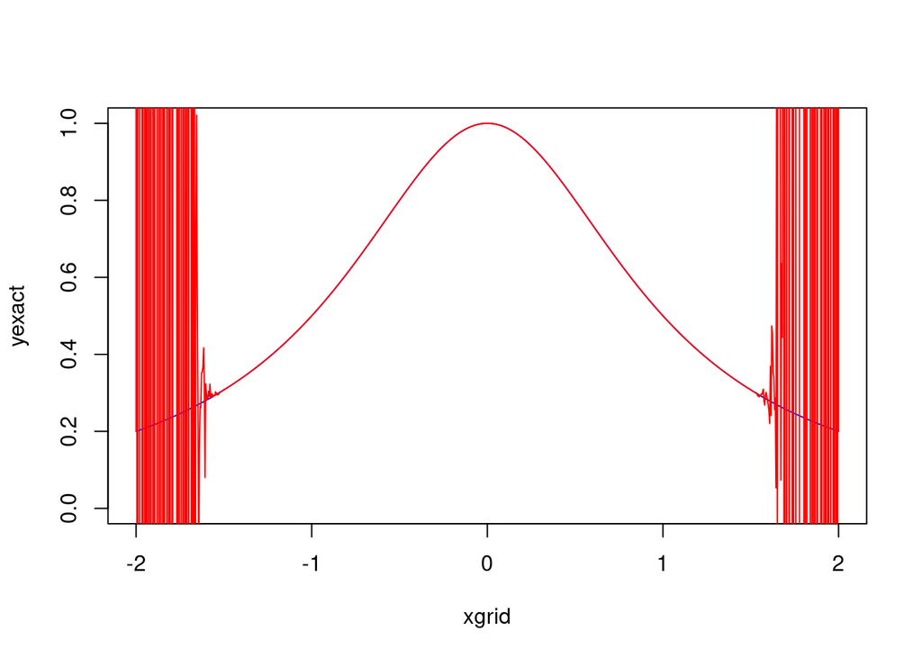

```r
f <- function(x){1/(1+x^2)}
xsample <- seq(from=-2, to=2, length=100)
xgrid <- seq(from=-2, to=2, length=1000)
yexact <- f(xgrid)
yinterp <- lagrange(xsample,f(xsample),xgrid)
plot(xgrid,yexact, type = "l", col = "blue", ylim = c(0,1))
lines(xgrid, yinterp, type = "l", col = "red")
```

```r
Norm(yexact - yinterp, p = Inf)
```

```
## [1] 271756799994
```

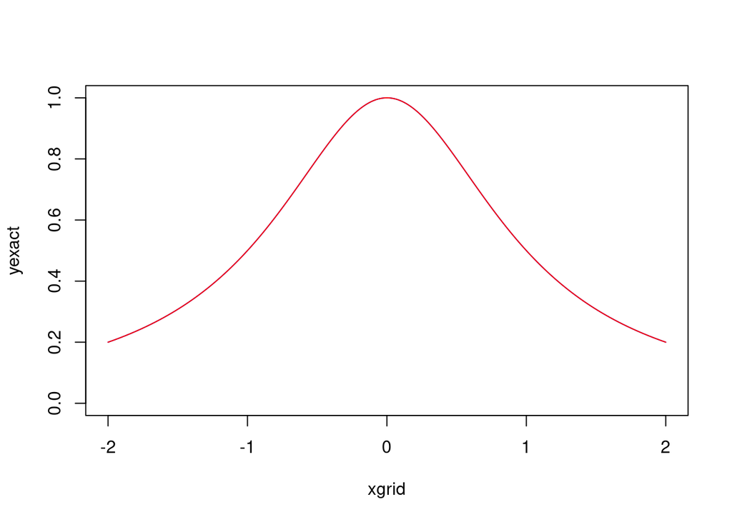

```r
a <- -2
b <- 2
n <- 100
i <- 1:n
xsample <- sort((b+a)/2 + (b-a)/2*cos((2*i-1)*pi/2/n))
xgrid <- seq(from=a, to=b, length=1000)
yexact <- f(xgrid)
yinterp <- lagrange(xsample,f(xsample),xgrid)
plot(xgrid,yexact, type = "l", col = "blue", ylim = c(0,1))
lines(xgrid, yinterp, type = "l", col = "red")
```

```r
Norm(yexact - yinterp, p = Inf)
```

```
## [1] 2.997602e-15
```